# Discussion 1

Dmitriy Izyumin

January 8, 2017

### Simple Linear Regression

For this example we’ll use Sir Galton’s midparent data. This data set contains pairs of observations corresponding to the height of a child, and the average height of the child’s parents.

```r
dat = read.table('midparents.txt', header=T)
names(dat)
```

```
## [1] "Child"     "Midparent"
```

```r
head(dat)
```

```
##   Child Midparent
## 1  61.7      70.5
## 2  61.7      68.5
## 3  61.7      65.5
## 4  61.7      64.5
## 5  61.7      64.0
## 6  62.2      67.5
```

For convenience, let’s rename the columns of the data frame.

```r
names(dat) = c('y', 'x')
```

We can also take a look at a brief summary of the data.

```r
summary(dat)
```

```
##        y               x
##  Min.   :61.70   Min.   :64.00
##  1st Qu.:66.20   1st Qu.:67.50
##  Median :68.20   Median :68.50
##  Mean   :68.09   Mean   :68.31
##  3rd Qu.:70.20   3rd Qu.:69.50
##  Max.   :73.70   Max.   :73.00
```

Before fitting a regression model, it’s useful to take a look at a scatterplot of the variables, and their correlation coefficient. At this point, we want to see if a linear relationship seems appropriate.

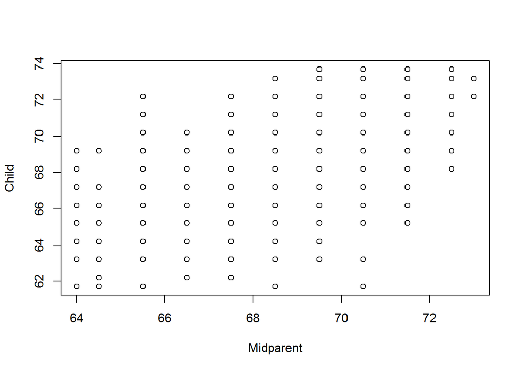

```r
plot(x=dat$x, y=dat$y, xlab='Midparent', ylab='Child')
```

```r
cor(dat)
```

```
##           y         x
## y 1.0000000 0.4587624
## x 0.4587624 1.0000000
```

Now we fit a linear regression model.

```r
fit = lm(y~x, data=dat)
```

The summary table includes a lot of useful things, such as parameter estimates, their standard errors, the corresponding t statistics, measures of association ($R^2$ and $R^2_{adj}$), and more.

```r
summary(fit)
```

```
##
## Call:
## lm(formula = y ~ x, data = dat)
##
## Residuals:
##     Min      1Q  Median      3Q     Max
## -7.8050 -1.3661  0.0487  1.6339  5.9264
##
## Coefficients:
##             Estimate Std. Error t value Pr(>|t|)
## (Intercept) 23.94153    2.81088   8.517   <2e-16 ***
## x            0.64629    0.04114  15.711   <2e-16 ***
## ---
## Signif. codes:  0 '***' 0.001 '**' 0.01 '*' 0.05 '.' 0.1 ' ' 1
##
## Residual standard error: 2.239 on 926 degrees of freedom
## Multiple R-squared:  0.2105, Adjusted R-squared:  0.2096
## F-statistic: 246.8 on 1 and 926 DF,  p-value: < 2.2e-16
```

Once we fit a model, we can obtain the fitted values and residuals.

```r
yhat = fit$fitted
res = fit$residuals
```

We can also obtain the ANOVA table.

```r
anova(fit)
```

```
## Analysis of Variance Table
##
## Response: y
##            Df Sum Sq Mean Sq F value    Pr(>F)
## x           1 1236.9 1236.93  246.84 < 2.2e-16 ***
## Residuals 926 4640.3    5.01
## ---
## Signif. codes:  0 '***' 0.001 '**' 0.01 '*' 0.05 '.' 0.1 ' ' 1
```

After fitting a model, we typically want to look at some diagnostic plots. The purpose is to see whether the model seems to be a good fit to the data, or if some assumptions seem violated.

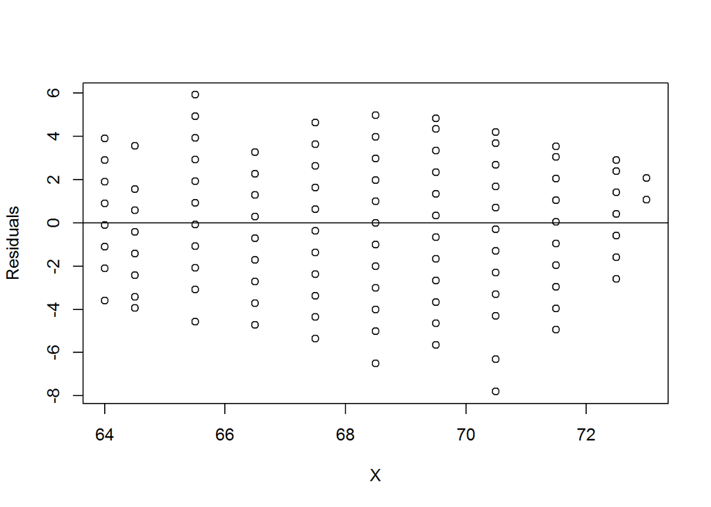

```r
plot(x=dat$x, y=res, xlab='X', ylab='Residuals')
abline(h=0)
```

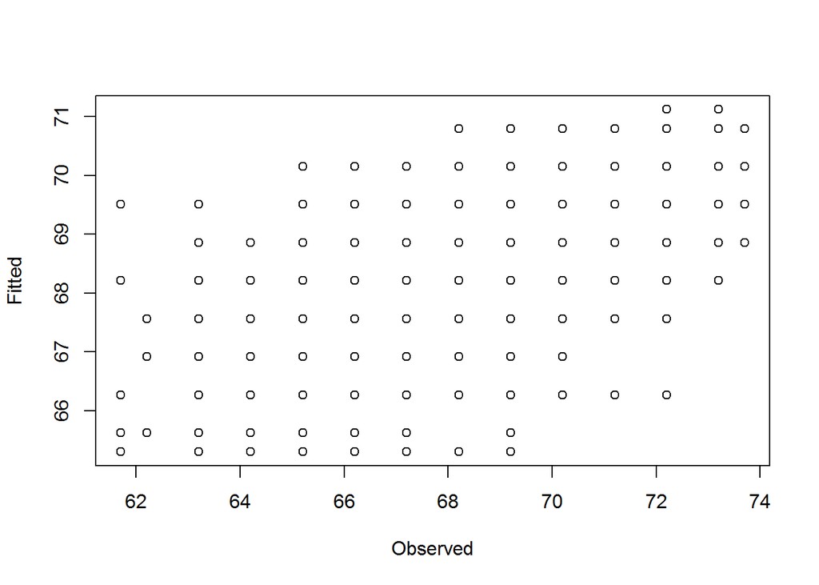

```r
plot(x=dat$y, y=yhat, xlab='Observed', ylab='Fitted')
abline(h=0)
```

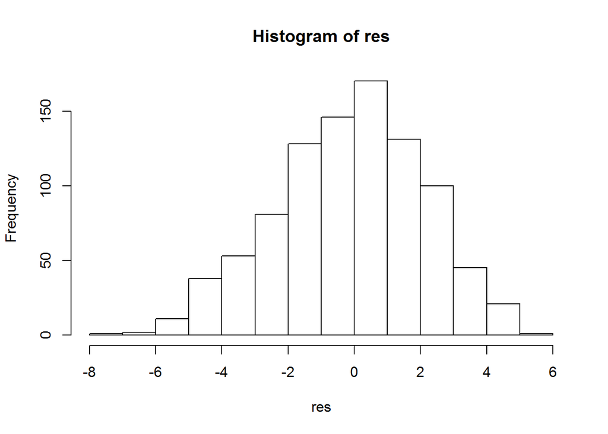

```r
hist(res)
```

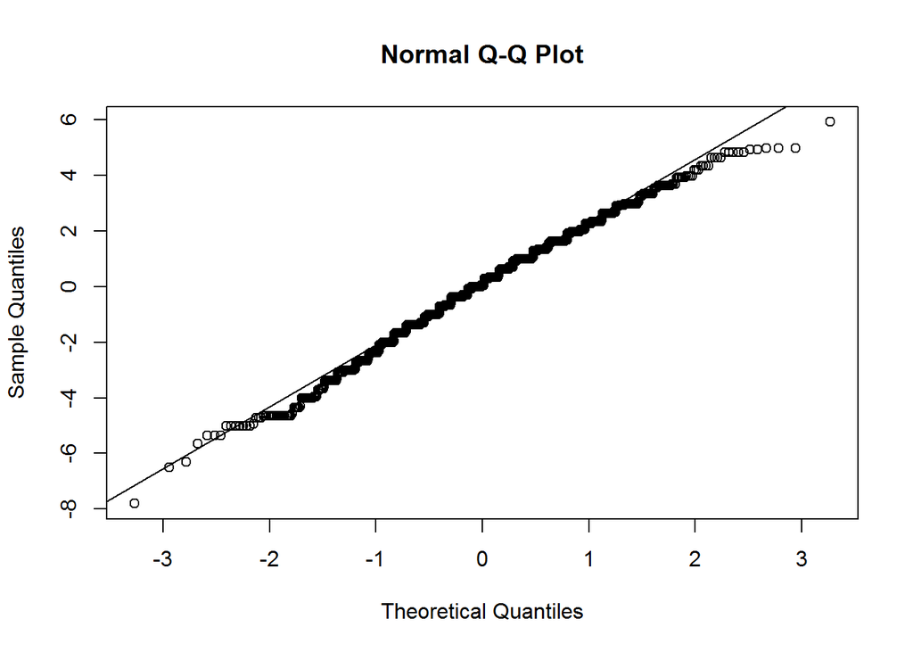

```r
qqnorm(res); qqline(res)
```

```r
shapiro.test(res)
```

```
##
##  Shapiro-Wilk normality test
##
## data:  res
## W = 0.99275, p-value = 0.0001697
```

### Multiple Regression

For this example we’ll use a data set from the regression textbook.

```r
dat = read.table('CH06PR15.txt', header=T)
names(dat) = c('y', 'x1', 'x2', 'x3')
head(dat)
```

```
##    y x1 x2  x3
## 1 48 50 51 2.3
## 2 57 36 46 2.3
## 3 66 40 48 2.2
## 4 70 41 44 1.8
## 5 89 28 43 1.8
## 6 36 49 54 2.9
```

First we want to look at the scatterplot matrix and the correlation matrix.

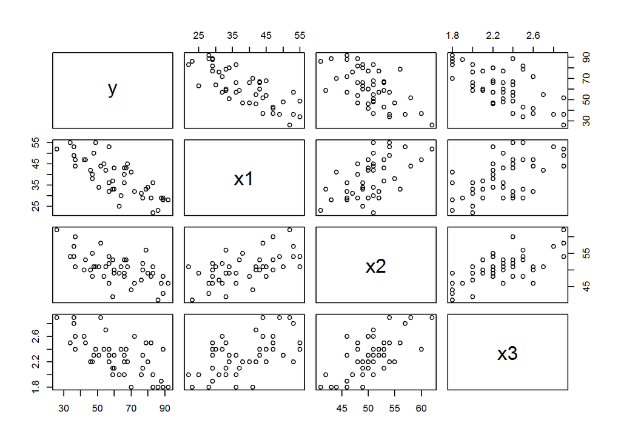

```r
plot(dat)
```

```r
cor(dat)
```

```
##             y         x1         x2         x3
## y   1.0000000 -0.7867555 -0.6029417 -0.6445910
## x1 -0.7867555  1.0000000  0.5679505  0.5696775
## x2 -0.6029417  0.5679505  1.0000000  0.6705287
## x3 -0.6445910  0.5696775  0.6705287  1.0000000
```

Fit a multiple regression model,

```r
fit = lm(y ~ x1 + x2 + x3, data = dat); fit
```

```
##
## Call:
## lm(formula = y ~ x1 + x2 + x3, data = dat)
##
## Coefficients:
## (Intercept)           x1           x2           x3
##     158.491       -1.142       -0.442      -13.470
```

Or equivalently,

```r
fit = lm(y ~ ., data = dat); fit
```

```
##
## Call:
## lm(formula = y ~ ., data = dat)
##
## Coefficients:
## (Intercept)           x1           x2           x3
##     158.491       -1.142       -0.442      -13.470
```

Most of what we’ve learned for simple regression carries over for multiple regression. For example, to extract the residuals from the lm object ‘fit’, we would use the familiar `fit$res`.